# NEW Tomato Bolognese

Helen Liu

2020-07-02

[figure not shown]

義大利肉醬是以洋蔥、番茄、豬肉、燻肉與義式香料為基底的一道百搭醬汁。其中意式綜合香料組合有許多種，通常包含奧勒岡(泥土味)、羅勒(甜味)、迷迭香(辛味、苦味)、大蒜(辛味)、大紅椒(甜味、辛味)、馬郁蘭(甜味、苦味)、黑胡椒(辛味)、月桂葉(辛味、苦味)、荳蔻(辛味)、芫荽(泥土味)等。

Master’s Thesis : Chapter 3.7.3 II.NEW Tomato Bolognese

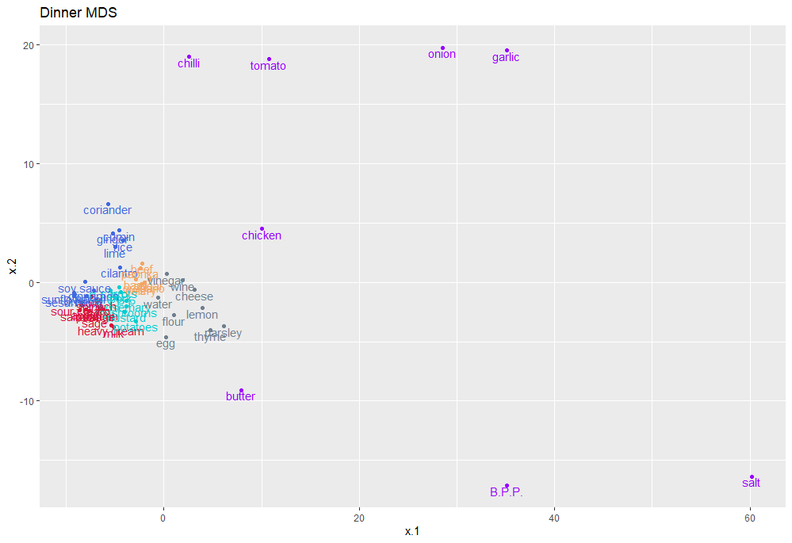

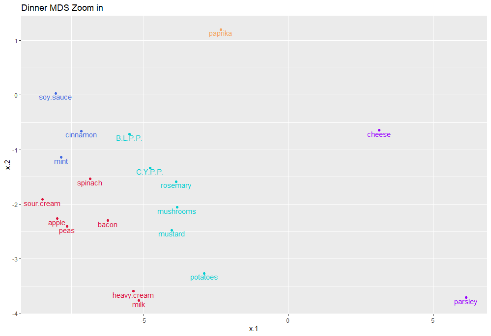

X.1、X.2座標為食譜的線性組合；  
晚餐食譜網站來源比例 : ALDI 830篇、cookingchanneltv 1394篇、jamieoliver 715篇、pinchOfYum 207篇

[Bolognese sauce from Jamie Oliver](https://www.jamieoliver.com/recipes/sauce-recipes/bolognese-sauce/)